# Caso Práctico 06: BMW vs Volkswagen

Daniel Corral Ruiz

13-12-2020

## Objetivos informe

Utilizando datos diarios de los dos series desde el año 2014, debemos analizar la relación entre BMW y Volkswagen, contestando a las siguiente preguntas:

- ¿Están cointegradas?

## Carga de datos

Comenzamos cargando el dataset mediante la librería “quantmod”. Esta librería nos permite obtener la información financiera de empresas durante un periodo de tiempo determinado. Descargamos los datos de BMW y Volkswagen entre 2014-01-01 y 2020-11-20.

## Estudiar cointegración

```
##
##  Augmented Dickey-Fuller Test
##
## data:  datajunto[, 1]
## Dickey-Fuller = -3.0272, Lag order = 0, p-value = 0.1435
## alternative hypothesis: stationary
```

```
##
##  Augmented Dickey-Fuller Test
##
## data:  datajunto[, 2]
## Dickey-Fuller = -2.3563, Lag order = 0, p-value = 0.4275
## alternative hypothesis: stationary
```

Hemos realizado el test de Dickey-Fuller para determinar la existencia o no de raíces unitarias en una serie de tiempo. La hipótesis nula de esta prueba es que existe una raíz unitaria en la serie. Como obtenemos en ambas serie un p-valor mayor a 0.05, aceptamos Ho, por lo tanto no son estacionarias.

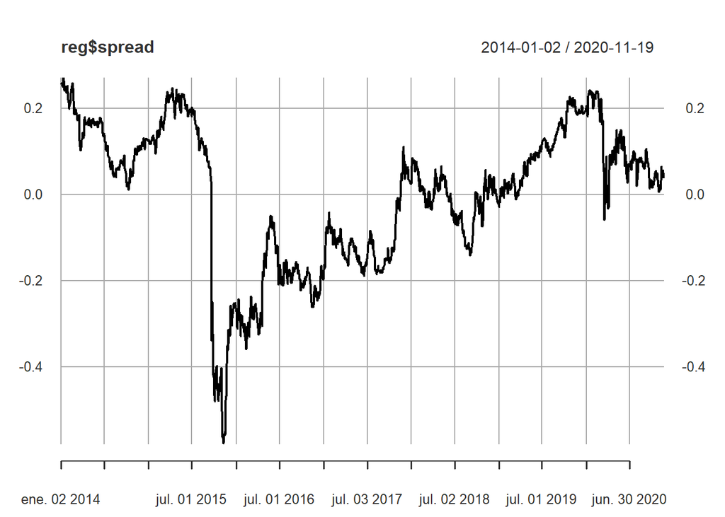

```
##  PP.test adf.test
##    FALSE    FALSE
```

```
## Response: x
## Input: y
## Number of inputs: 1
## Model: y ~ X + 1
## -------------------------------
## Engle-Granger Cointegration Test
## alternative: cointegrated
##
## Type 1: no trend
##     lag      EG p.value
##  7.0000 -2.7771  0.0646
## -----
##  Type 2: linear trend
##     lag      EG p.value
##   7.000  -0.274   0.100
## -----
##  Type 3: quadratic trend
##     lag      EG p.value
##    7.00    1.55    0.10
## -----------
## Note: p.value = 0.01 means p.value <= 0.01
##     : p.value = 0.10 means p.value >= 0.10
```